# Introduction to R

Session 4

## Session Overview

1. Data manipulation
2. Graphics
3. Graphics: Advanced Graphics with ggplot

# Basics of Data Manipulation

## Data Manipulation

In the last session, we learned how to load data of various sources into R.

Today’s first part will be about how to manipulate data in R. Importantly, we will learn how to

- select certain variables from a data
- subset a data set
- recode and rename certain variables

We will work with fictive data set of student grades. We start by downloading the grades.csv file from the training website, setting our working directory and loading the data:

```r
library(this.path)
setwd(here())
data_grades <- read.table("data/grades.csv",
                       header = TRUE, sep = ",", stringsAsFactors = FALSE)
```

## Selecting Variables

We begin with selecting interesting variables from a data set. For our grades data set, we want to preserve information about `ID`, `Name`, and `Exam_Score`, and drop all other information.

Variables can be selected by name, after which we inspect the first and last three rows in the data set:

```r
data <- data_grades[, c("ID", "Name", "Exam_Score")]
head(data, 3)
```

```
      ID                Name Exam_Score
1 i40333 Hyden-Terry, Dakota         55
2 i41204     Polson, Destiny         82
3 i41428       al-Azad, Nuha         52
```

```r
tail(data, 3)
```

```
        ID             Name Exam_Score
40 i198051      Nies, Tyler         62
41 i198310 Montano, Marquez         72
42 i198859  Nyberg, Bich Sa         91
```

## Selecting Variables

Or by variable indexes

```r
data1 <- data_grades[, c(1, 2, 7)]
```

though this is not that convenient unless you know the column numbers of the variables you want to select.

A more convenient alternative is to use the following function:

```r
data2 <- subset(data_grades, select = c(ID, Name, Exam_Score))
```

The objects data, data1 and data2 are all identical so you can use your preferred way of working!

## Subsetting Rows

Next, we want to subset the data set, i.e. preserve interesting rows while removing the others.

For the grades data set, we might be interested in information about students in tutorial group 1:

```r
# select tutorial 1 students only
data_tutorial1 <- data_grades[data_grades$Tutorial == 1, ]
```

or alternatively:

```r
data_tutorial1 <- subset(data_grades, Tutorial == 1)
```

Subsetting also works using characters. For instance, to retrieve only information for females:

```r
# select female students only
data_females <- data_grades[data_grades$Gender == 'Female', ]
```

Inspect your new data sets!

## Exercise 4.1

Use the grades data set.

1. Generate a data set that contains information about the student ID, student name, their tutorial group, participation grade and their exam score.
2. Further reduce the data set obtained under 1 to only display information of students in tutorial group 4.
3. Further reduce the data set obtained under 2 to only display information of students with an exam score of more than 80. How many such students are there?

## Transforming Variables

Let us continue with further data manipulations. The variable `Tutorial` is currently an integer:

```r
class(data_grades$Tutorial)
```

```
[1] "integer"
```

but it should be a factor (a categorical variable). This can be easily changed in R:

```r
data_grades$Tutorial <- as.factor(data_grades$Tutorial)
```

after which you can inspect its new class:

```r
class(data_grades$Tutorial)
```

```
[1] "factor"
```

## Transforming Variables

When inspecting the variable itself, R now mentions the different levels of the factors:

```r
data_grades$Tutorial
```

```
 [1] 2 3 4 2 1 4 3 1 1 3 4 2 4 4 3 1 3 4 1 2 1 1 3 1 3 3 2 3 2 1 4 4 4 2 3 2 2 4
[39] 4 2 1 3
Levels: 1 2 3 4
```

which you can also directly retreive via:

```r
levels(data_grades$Tutorial)
```

```
[1] "1" "2" "3" "4"
```

## Adding Variables

Sometimes we want to add a variable to an existing data set.

For instance, we want to add the exam score on 10 instead of 100. To add a new variable, use the `$` operator and specify a new variable name:

```r
data_grades$Exam_Score_10 <- data_grades$Exam_Score/10

head(data_grades[, c("Exam_Score", "Exam_Score_10")], 3)
```

```
  Exam_Score Exam_Score_10
1         55           5.5
2         82           8.2
3         52           5.2
```

## Exercise 4.2

1. What is the class of the variable Tutor? Transform it into a factor. How many tutors are there?
2. Add a new variable to compute the final score of each student, which is the weighted average of their participation grade (20%) and their exam score (80%)
3. Retrieve the final score of the students in tutorial group 2. Obtain summary statistics of their final scores.
4. What is the lowest and the highest final score in tutorial group 2? Retrieve this information from the summary statistics as well as by using a dedicated function.

## R Base Graphics

- We will cover R base graphics.
- Other alternatives include `ggplot2’…

To create plots with R’s standard `graphics` package, there are *high-level* and *low-level* plotting functions.

- *High-level* functions generate a new graphic (and open a *device*).
- *Low-level* functions add elements to an existing graphic.

## Simple plots

```r
load('data/climate_long.Rdata')
plot(long_data$TEMP)     ## Plotting a single variable
```

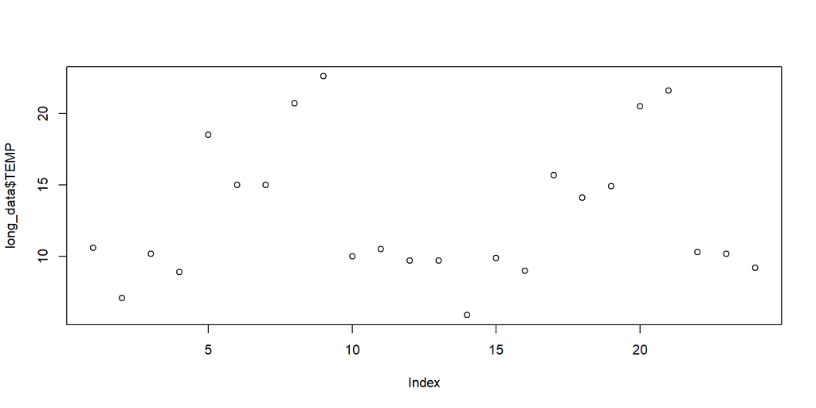

## Simple plots

```r
plot(x = long_data$MONTH, y = long_data$TEMP)     ## Scatter plot wrt month
```

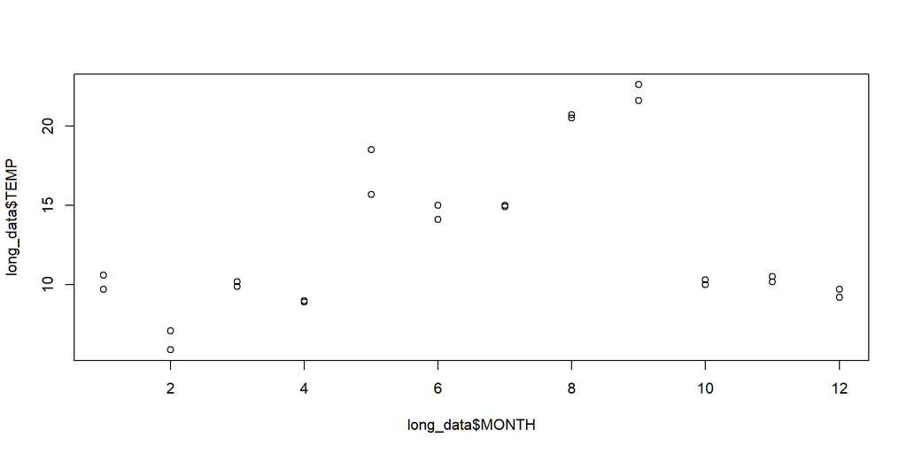

## Multiple plots

```r
par(mfrow = c(1,2)) # multiple plots in a row
plot(long_data$TEMP)     ## Plotting a single variable
plot(x = long_data$MONTH, y = long_data$TEMP)     ## Scatter plot wrt month
```

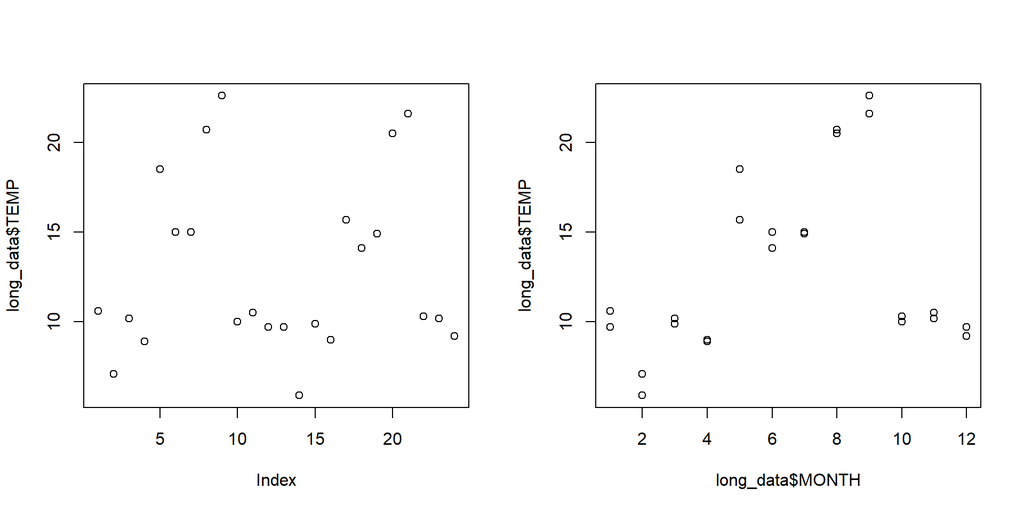

## Functions calling methods

Notice that function `plot()` calls methods.

It will perform different operations depending on the class of the passed object. (We study the `lm()` function in detail in the next session!)

```r
ols_result <- lm(TEMP~MONTH, data = long_data)
plot(ols_result)
```

## Exercise 4.3: Load data from Yahoo Finance, and see how plot function behaves.

- Retrieve the AAPL series from Yahoo Finance from January first 2024 until today (see Session 1). You can use

```r
library(quantmod)
getSymbols("AAPL", src = "yahoo", from = "2024-01-01", to = Sys.Date())
```

- Plot the whole dataset
- Plot a selected column, for example closing prices `AAPL$AAPL.Close`
- Comment on the x axis of the data and how it is different from the plots we considered earlier.
- The difference is due to the quantmod package.